# Note-Optimization

Weiquan Luo

Updated by 2021-01-21

### Prerequisites

```r
# Optimization in R: https://www.is.uni-freiburg.de/resources/computational-economics/5_OptimizationR.pdf

library(stats) # General purpose
library(lpSolve) # Linear Programming
library(quadprog) # Quadratic Programming
library(optimx) # Non-Linear Programming

options(digits=6)
library(dplyr)
```

# 1. Introduciton

Common R packages for optimization

| Problem type | Package::function |
| --- | --- |
| General purpose (1-dim.) | `stats::optimize()` |
| General purpose (n-dim.) | `stats::optim()` |
| Linear Programming | `lpSolve::lp()` |
| Quadratic Programming | `quadprog::solve.QP()` |
| Non-Linear Programming | `optimx::optimx()` |
| General interface | `ROI::ROI_solve()` |

## 1.1 Common Method

- Linear Programming
- Quadratic Programming
- Non-Linear Programming

## 1.2 Elements

- Objective function
- Constraints

# 2. General purpose

`stats::optim(par, fun, ...)` is for n-dimensional general purpose optimization.

- Argument `par` sets the initial values of the search
- `fn` specifies a function to optimize over
- Optional, named argument `method` chooses an algorithm

```r
# Define objective function and initial value
objfun <- function(x) 2*(x[1]-1)^2 + 5*(x[2]-3)^2 + 10
init_x <- c(1, 1)
# Call optimization routine
op_result <- stats::optim(par = init_x, fn = objfun)
# optimizatized Objective
op_result$par
```

```
## [1] 1.00017 3.00023
```

```r
# Optimal input values
op_result$value
```

```
## [1] 10
```

# 3. Linear Programming

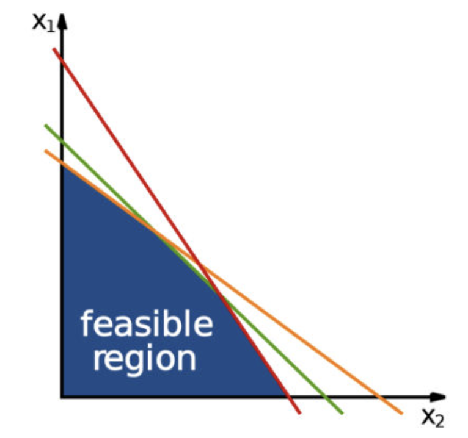

Linear Programming in Dim(x) = 2

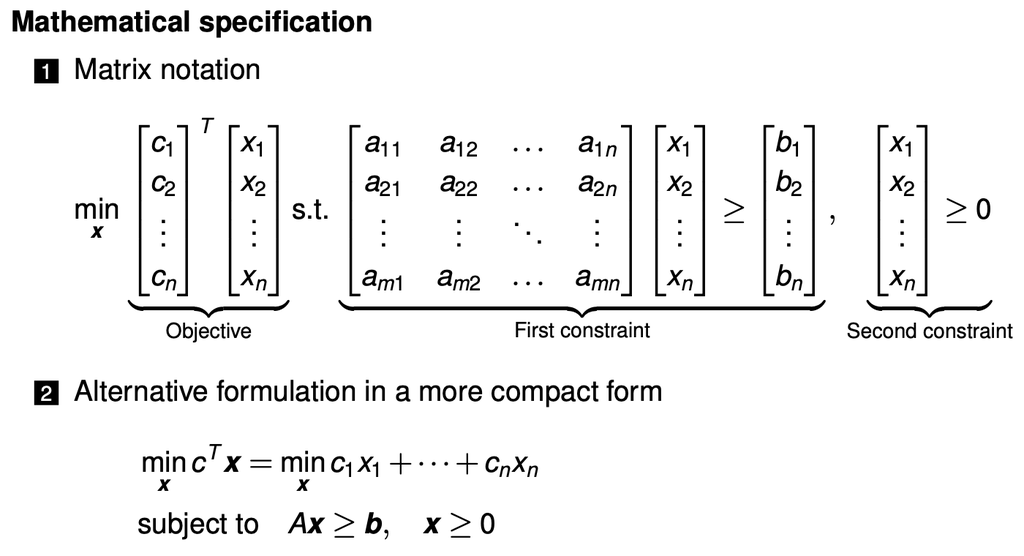

Linear Programming Mathematical specification

`lpSolve::lp(direction="min", objective.in, const.mat, const.dir, const.rhs)` is for n-dimensional Linear Programming optimization.

e.g. maximize the total profit

```r
# objective function
const.mat <- matrix(c(20, 12, 1/15, 1/15), nrow=2, byrow=TRUE)
# initial value
objective.in <- c(25, 20)
# constraints
const.dir <- c("<=", "<=")
const.rhs <- c(1800, 8)
# Call optimization routine
op_result <- lpSolve::lp(direction="max",  objective.in = objective.in,
                         const.mat = const.mat, const.rhs = const.rhs,
                         const.dir = const.dir)
# Optimal input values
op_result$solution
```

```
## [1] 45 75
```

```r
# optimizatized Objective
op_result$objval
```

```
## [1] 2625
```

# 4. Quadratic Programming

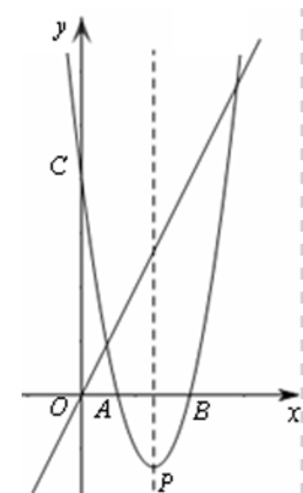

Quadratic Programming in Dim(x) = 1

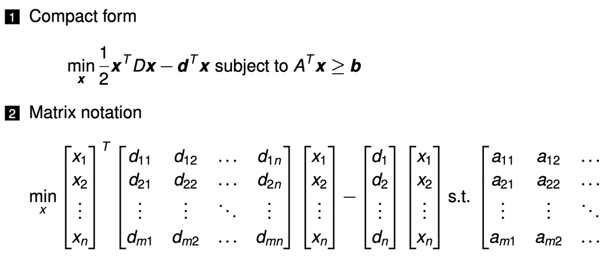

Quadratic Programming Mathematical specification

`quadprog::solve.QP(Dmat, dvec, Amat, bvec, meq=0, factorized=FALSE)` is for n-dimensional Quadratic Programming optimization.

e.g.,portfolio optimization, circus tent problem, demand response

```r
# objective function
Dmat <- matrix(0,3,3); diag(Dmat) <- 1
dvec <- c(0,5,0)
# initial value
## N.A.
# constraints
Amat <- matrix(c(-4,-3,0,2,1,0,0,-2,1),3,3)
bvec <- c(-8,2,0)
# Call optimization routine
op_result <- quadprog::solve.QP(Dmat,dvec,Amat,bvec=bvec)
# Optimal input values
op_result$solution
```

```
## [1] 0.47619 1.04762 2.09524
```

```r
# optimizatized Objective
op_result$value
```

```
## [1] -2.38095
```

# 5. Non-Linear Programming

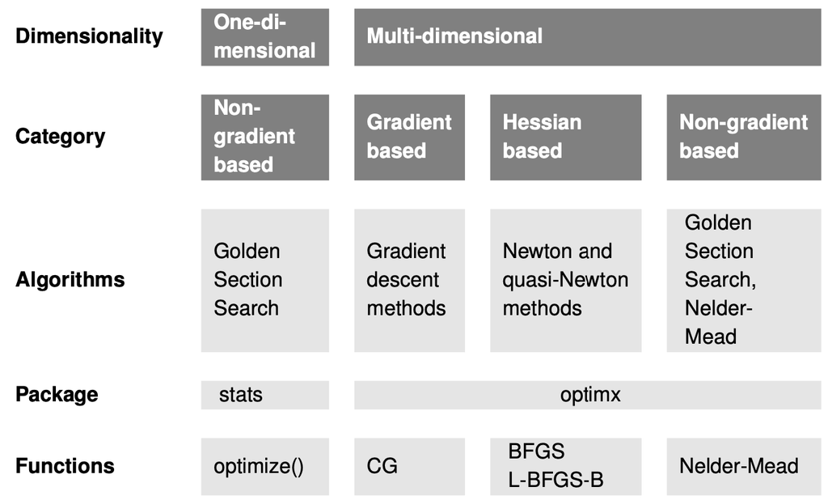

Overview: Non-Linear Optimization

`optimx::optimx(par, fn, gr=Null, Hess=Null, lower=inf, upper=inf, method='', itnmax=Null, ...)` provides collection of for Non-Linear Multi-Dimensional Programming methods.

## 5.1 Method

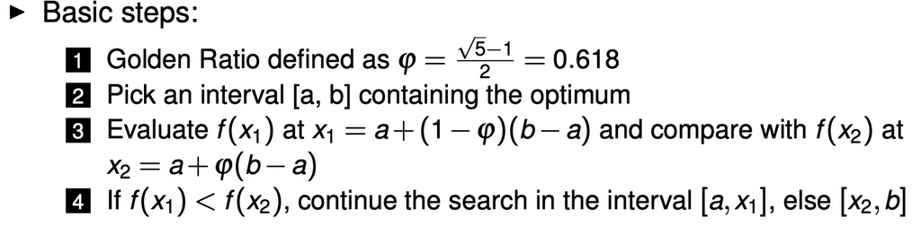

Basic steps of Golden Section Search

### 5.1.2 Nelder-Mead

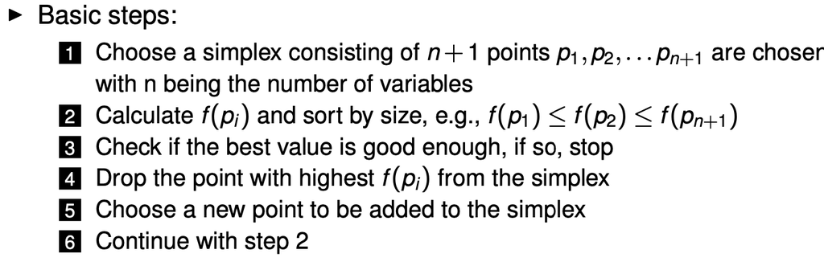

Basic steps of Nelder-Mead

### 5.1.3 Conjugate Gradients

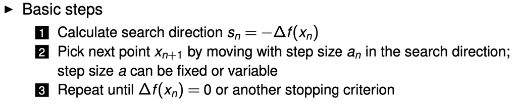

Basic steps of Conjugate Gradients

### 5.1.4 Newton-Raphson

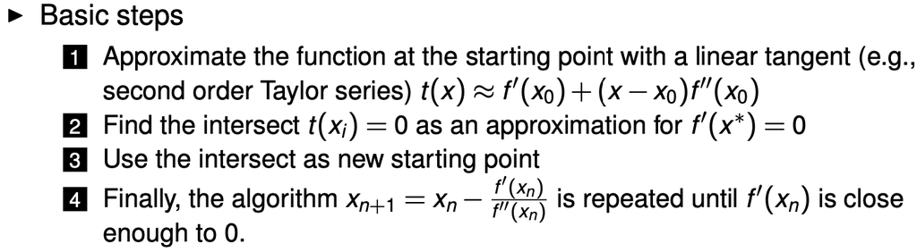

Basic steps of Newton-Raphson

### 5.1.5 BFGS and L-BFGS-B

Broyden-Fletcher-Goldfarb-Shanno(BFGS) algorithm builds on the idea of Newton’s method to take gradient information into account. Gradient information comes from an approximation of the Hessian matrix. No guaranteed conversion; expecially problematic if Taylor expansion does not fit well.

- Extension of BFGS
- Memory efficient implementation
- Additionally handles box constraints

## 5.1 1-dimensional Non-Linear optimization.

`stats::optimize(f, interval, tol, maximum = FALSE)` is for 1-dimensional Non-Linear optimization using Golden Section Search.

```r
# ifferentiable function
f <- function(x)(x - 1/3)^2
op_result <- stats::optimize(f, interval = c(0, 1), tol = 0.0001)
# Non-differentiable function
f <- function(x) return(abs(x-2) + 2*abs(x-1))
op_result <- optimize(f, interval = c(0, 3), tol = 0.0001)
# Optimal input values
op_result$minimum
```

```
## [1] 1.00001
```

```r
# optimizatized Objective
op_result$objective
```

```
## [1] 1.00001
```

## 5.2 n-dimensional Non-Linear optimization.

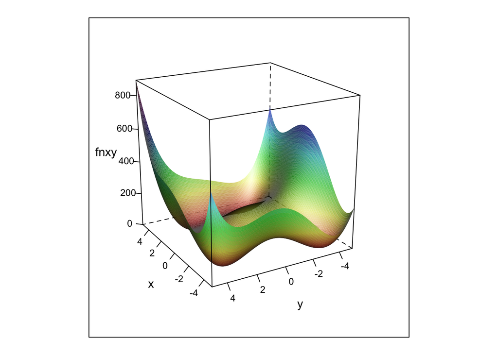

```r
# objective function: Himmelblau’s function
fn <- function(para){ # Vector of the parameters
  matrix.A <- matrix(para, ncol=2)
  x <- matrix.A[,1]
  y <- matrix.A[,2]
  f.x <- (x^2+y-11)^2+(x+y^2-7)^2
  return(f.x)
}

xy <- as.matrix(expand.grid(seq(-5,5,length = 101), seq(-5,5,length = 101)))
colnames(xy) <- c("x", "y")
df <- data.frame(fnxy = fn(xy), xy)
library(lattice)
wireframe(fnxy ~ x*y, data = df, shade = TRUE, drape=FALSE,
          scales = list(arrows = FALSE), screen = list(z=-240, x=-70, y=0))
```

```r
# initial value
par <- c(1,1)
# Call optimization routine: compare search methods
optimx(par, fn, control=list(all.methods=TRUE, save.failures=TRUE, trace=0)) %>%
  `rownames<-`(rownames(.)) %>%
  mutate(method = rownames(.)) %>%
  select(method, everything()) %>%
  mutate_if(is.numeric, signif, digits = 6) %>%
  DT::datatable(.)
```

|  | method | p1 | p2 | value | fevals | gevals | niter | convcode | kkt1 | kkt2 | xtime |
| --- | --- | --- | --- | --- | --- | --- | --- | --- | --- | --- | --- |
| 1 | BFGS | 3 | 2 | 1.35419e-12 | 32 | 11 |  | 0 | True | True | 0.001 |
| 2 | CG | 3 | 2 | 1.08123e-12 | 119 | 31 |  | 0 | True | True | 0.001 |
| 3 | Nelder-Mead | 3 | 2.00018 | 5.56163e-07 | 67 |  |  | 0 | False | True | 0 |
| 4 | L-BFGS-B | 3 | 2 | 1.15944e-15 | 13 | 13 |  | 0 | True | True | 0 |
| 5 | nlm | 3 | 2 | 1.45038e-14 |  |  | 10 | 0 | True | True | 0.001 |
| 6 | nlminb | 3 | 2 | 4.48785e-21 | 16 | 27 | 12 | 0 | True | True | 0.001 |
| 7 | spg |  |  | 8.98847e+307 |  |  |  | 9999 |  |  | 0.001 |
| 8 | ucminf | 3 | 2 | 8.4095e-11 | 11 | 11 |  | 0 | True | True | 0.004 |
| 9 | Rcgmin | 3 | 2 | 1.05156e-14 | 31 | 20 |  | 0 | True | True | 0.002 |
| 10 | Rvmmin | 3 | 2 | 8.35298e-15 | 17 | 13 |  | 0 | True | True | 0.003 |

[output cut: 4 more lines]

```r
# Call optimization routine: apply specific method
optimx(par, fn, method = c("CG")) %>% mutate_if(is.numeric, signif, digits = 6) %>% DT::datatable(.)
```

|  | p1 | p2 | value | fevals | gevals | niter | convcode | kkt1 | kkt2 | xtime |
| --- | --- | --- | --- | --- | --- | --- | --- | --- | --- | --- |
| 1 | 3 | 2 | 1.08123e-12 | 119 | 31 |  | 0 | True | True | 0.001 |